# Rad s objektima i podacima u R-u

2024-10-07

## Sadržaj praktikuma

- Uvod u rad u programskom okruženju R i osnovne funkcije, instaliranje programskih paketa
- Unos podataka u programsko okruženje R, struktura objekata
- **Rad s objektima i podacima te definiranje bioloških varijabli u R-u**
- Grafički prikaz bioloških podataka i testiranje razdiobe podataka u R-u
- Primjeri osnovnih statističkih analiza kategoričkih i numeričkih varijabli u biološkim istraživanjima u R-u
- Regresije i korelacije, linearni modeli bioloških podataka – primjeri u R-u
- Primjena parametrijskih statističkih testova bioloških podataka u R-u
- Primjena neparametrijskih statističkih testova bioloških podataka u R-u
- Primjeri multivarijatnih analize bioloških podataka u R-u - linearni modeli, klaster analize i ordinacijske analize

## Sadržaj današnje vježbe

- odabir samo određenih varijabli iz seta podataka - naredba `select()`
- filtriranje uzoraka oadranih karakteristika - naredba `filter()`
- kreiranje nove varijable - naredba `mutate()`
- grupiranje rezultata po varijablama - naredba `group_by()`
- prikaz rezultata prosjeka varijabli po grupama - `naredba summarize()`
- uklanjanje nedostajućih vrijednosti - naredba `na.omit()`
- pisanje koda s pipe opetatorom (`%>%`)

## Uvod u Tidyverse

[figure not shown]

- **Tidyverse** je skup međusobno povezanih R paketa osmišljenih za olakšavanje **rada s podacima**.
- Osnovna filozofija Tidyverse-a je **“tidy” (uredan) oblik podataka**, gdje su podaci organizirani u tabličnom formatu (**redovi predstavljaju opažanja**, a **stupci varijable**).
- Omogućava intuitivno i efikasno manipuliranje, analiziranje i vizualiziranje podataka.
- Istovjetne naredbe ponekad su dostupne i u base R-u, ali tidyverse je češće korišten u praksi i pruža puno više mogućnosti za rad s podacima.

## Osnovni paketi u Tidyverse-u

[figure not shown]

- **ggplot2** – Napredna i fleksibilna vizualizacija podataka.
- **dplyr** – Efikasna manipulacija podacima (filtriranje, sortiranje, agregacija).
- **tidyr** – Transformacija podataka u “tidy” format.
- **readr** – Učitavanje podataka iz tekstualnih datoteka (CSV, TSV).
- **tibble** – Poboljšani rad s tablicama, alternativa data.frame-u.

## Učitajmo tidyverse u R radno okruženje!

```r
# Paketi iz tidyverse-a se mogu učitati svi skupa
library(tidyverse)
```

```r
# Paketi Tidyverse-a se mogu i zasebno učitavati, npr. ggplot2
library(ggplot2)
```

## Set podataka o Palmer pingvinima

[figure not shown]

## Tablica s podacima o pingvinima

[figure not shown]

## Rad s podacima u R-u

**Podsjetimo se:** pregled trenutnog i postavljanje novog radnog direktorija.

```r
# predled trenutnog radnog direktorija
getwd()
```

```
## [1] "C:/Users/Hrvoje/Documents/APUBI/03_Rad_s_podacima"
```

```r
# postavljanje novog radnog direktorija
setwd("C:/Users/Hrvoje/Documents/APUBI/03_Rad_s_podacima")
```

## Učitavanje podataka iz Excel tablice

```r
# Učitavanje potrebnog paketa
library(readxl)
# Učitavanje podataka iz Excel tablice u objekt
penguins <- read_excel("palmerpenguins_original.xlsx")
```

**`View(penguins)`** # ili klik na objekt u environmentu

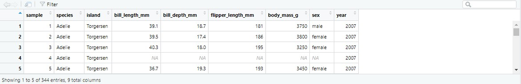

Provjera strukture tablice i tipa podataka.

```r
# Provjera tipa i strukture objekta
str(penguins)
```

```
## tibble [344 × 9] (S3: tbl_df/tbl/data.frame)
##  $ sample           : num [1:344] 1 2 3 4 5 6 7 8 9 10 ...
##  $ species          : chr [1:344] "Adelie" "Adelie" "Adelie" "Adelie" ...
##  $ island           : chr [1:344] "Torgersen" "Torgersen" "Torgersen" "Torgersen" ...
##  $ bill_length_mm   : num [1:344] 39.1 39.5 40.3 NA 36.7 39.3 38.9 39.2 34.1 42 ...
##  $ bill_depth_mm    : num [1:344] 18.7 17.4 18 NA 19.3 20.6 17.8 19.6 18.1 20.2 ...
##  $ flipper_length_mm: num [1:344] 181 186 195 NA 193 190 181 195 193 190 ...
##  $ body_mass_g      : num [1:344] 3750 3800 3250 NA 3450 ...
##  $ sex              : chr [1:344] "male" "female" "female" NA ...
##  $ year             : num [1:344] 2007 2007 2007 2007 2007 ...
```

## Pitanje na koje želimo odgovor je:

### **“Koja je prosječna masa pingvina vrste Adelie u kilogramima na svakom od otoka?”**

## Naredba **`select()`**

- Kako bi odgovorili na to pitanje, najlakše je stvroriti novi tablicu u kojoj ćemo **odabrati** samo one varijable koje su nam potrebne za izračun: species, island i body_mass_g.
- Naredba **`select()`** je funkcija iz dplyr paketa koja služi za odabir (selektiranje) specifičnih stupaca iz data frame-a. Pomaže u fokusiranju samo na one varijable (stupce) koje su potrebne za analizu, a ignorira ostatak podataka.
- Primjer: **`select(podaci, varijabla1, varijabla2, …)`**

## Naredba **`select()`**

```r
# Korak 1: Odabir relevantnih varijabli (stupaca)
select(penguins, # podaci
       species, # varijabla 1
       island, # varijabla 2
       body_mass_g)# varijabla 3
```

```
## # A tibble: 344 × 3
##    species island    body_mass_g
##    <chr>   <chr>           <dbl>
##  1 Adelie  Torgersen        3750
##  2 Adelie  Torgersen        3800
##  3 Adelie  Torgersen        3250
##  4 Adelie  Torgersen          NA
##  5 Adelie  Torgersen        3450
##  6 Adelie  Torgersen        3650
##  7 Adelie  Torgersen        3625
##  8 Adelie  Torgersen        4675
##  9 Adelie  Torgersen        3475
## 10 Adelie  Torgersen        4250
## # ℹ 334 more rows
```

## Gdje je objekt? Zašto nije u environmentu?

- Jer ga nismo spremili kao novi objekt!
- Kreirajmo novi objekt naziva **“penguins_selected”** u koji će se spremiti izabrane varijable.

```r
# Ponovimo korak 1, ali kreirajmo novi objekt u koji će se spremiti
penguins_selected <- select(penguins, species, island, body_mass_g)
```

**`View(penguins_selected)`** ili klik na objekt u environmentu za vizualizaciju nove tablice.

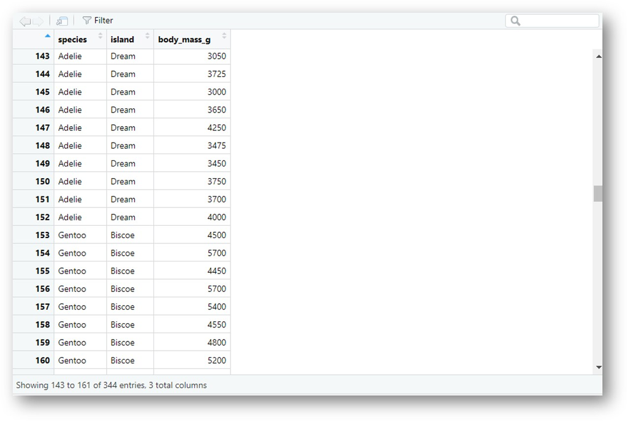

## Funkcija **`filter()`**

- **`filter()`** je funkcija iz dplyr paketa koja služi za filtriranje redova u *data frame*-u.
- Zadržava samo one redove koji zadovoljavaju specificirane uvjete.
- Čitljivost - Jasno izražava uvjete u kodu.
- Fleksibilnost - Moguće kombinirati više uvjeta korištenjem logičkih operatora (&, |). Primjer:

Naredbom **`filter()`** želimo od svih redova s vrstama pingvina zadržati samo pripadnike vrste Adelie.

```r
# Korak 2: Filtriranje uzoraka (redaka) vrste "Adelie"
penguins_adelie <- filter(penguins_selected, # podaci
                          species == "Adelie") # uvjet filtriranja
```

**`View(penguins_adelie)`** ili klik na objekt u environmentu za vizualizaciju nove tablice.

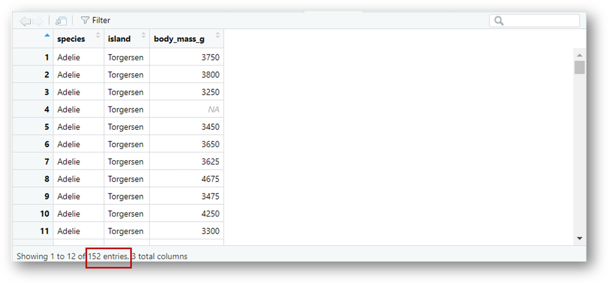

## Funkcija **`mutate()`**

- **`mutate()`** je funkcija iz dplyr paketa koja služi za kreiranje novih stupaca (varijabli) ili modifikaciju postojećih unutar data frame-a.
- Pomaže u dodavanju izmjenjenih varijabli bez potrebe za kreiranjem novog data frame-a.
- koristit ćemo funkciju **`mutate()`** kako bi kreirali novu varijablu koja prikazuje masu pingvina u kilogramima umjesto u gramima.

```r
# Korak 3: Kreiranje nove varijable koja sadrži masu izraženu u kilogramima
penguins_mass_kg <- mutate(penguins_adelie, # podaci
                           body_mass_kg = body_mass_g / 1000) # kreiranje nove varijable
```

**`View(penguins_mass_kg)`** ili klik na objekt u environmentu za vizualizaciju nove tablice.

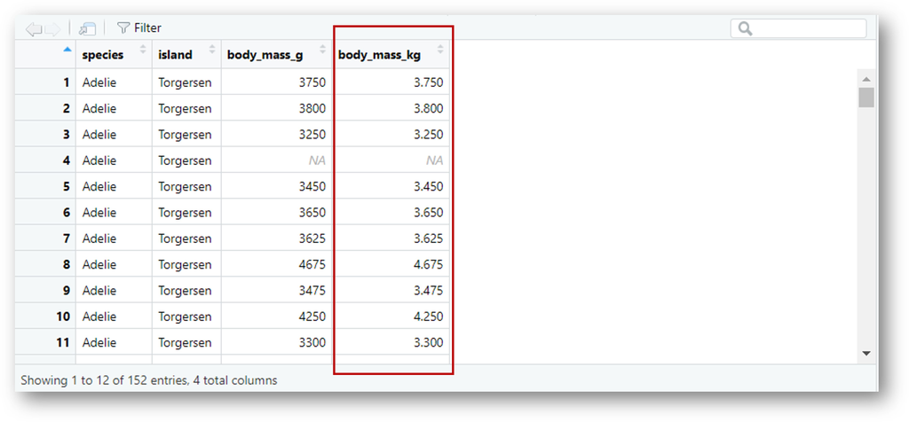

## Funkcija **`group_by()`** u R-u (dplyr)

- **`group_by()`** je funkcija iz dplyr paketa koja omogućava grupiranje podataka prema jednoj ili više varijabli.
- Koristi se često u kombinaciji s funkcijama poput **`summarise()`** za izvođenje agregatnih operacija unutar svake grupe.

```r
# Korak 4: Zadavanje grupiranja i prikaza rezultata po otocima
penguins_grouped <- group_by(penguins_mass_kg, # podaci
                             island) # varijabla po pokoj želimo grupirati
```

## Funkcija **`summarise()`**

- **`summarise()`** ili **`summarize()`** je funkcija iz dplyr paketa koja se koristi za sažimanje podataka na temelju agregatnih operacija.
- Najčešće se koristi u kombinaciji s **`group_by()`** kako bi se izračunale sumarizirane statistike unutar grupa.

```r
# Korak 5: Kreiranje finalne sumariziranje tablice rezultata
penguins_result <- summarise(penguins_grouped, # podaci
                             average_mass = mean(body_mass_kg)) # nova varijabla za prosjek

# Ispis konačnog rezultata
print(penguins_result)
```

```
## # A tibble: 3 × 2
##   island    average_mass
##   <chr>            <dbl>
## 1 Biscoe            3.71
## 2 Dream             3.69
## 3 Torgersen        NA
```

## **Zašto nam se ne prikazuju podaci za Torgersen otok?**

- Jer nismo uklonili nedostajuće vrijednosti!
- Koristiti funkciju na.omit().

### Funkcija **`na.omit()`**

- **`na.omit()`** funkcija iz *base* R-a koja se koristi za **uklanjanje redaka s nedostajućim vrijednostima (NA)** iz data frame-a ili vektora.
- Vraća filtrirani data frame bez redaka s NA vrijednostima.

```r
# Kako bi mogli izračunati rezultat za otok Torgersen moramo ukloniti nedostajuće podatke
# Uklanjanje uzoraka s nedostajućim podacima
penguins_cleaned <- na.omit(penguins_mass_kg)

# Ponovimo korake 4 i 5 s novom tablicom
# Korak 4: Zadavanje grupiranja i prikaza rezultata po otocima
penguins_grouped <- group_by(penguins_cleaned, island)
```

```r
# Korak 5: Kreiranje finalne sumariziranje tablice rezultata
penguins_result <- summarise(penguins_grouped, average_mass = mean(body_mass_kg))

# Ispis konačnog rezultata
print(penguins_result)
```

```
## # A tibble: 3 × 2
##   island    average_mass
##   <chr>            <dbl>
## 1 Biscoe            3.71
## 2 Dream             3.69
## 3 Torgersen         3.71
```

## **Odgovor na postavljeno pitanje pitanje s početka:**

**“Prosječna masa pingvina vrste Adelie na otoku Biscoe i Torgersen iznosila je 3.71 kg, a na otoku Dream 3.69 kg.”**

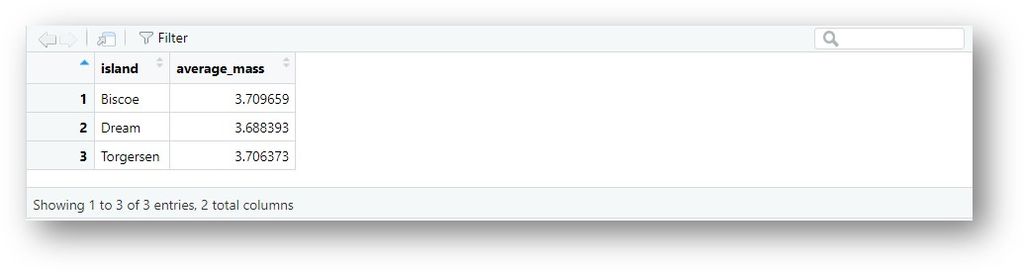

## Zadatak

- Koristeći gore naučene funkcije za manipulaciju podacima, kreirajte data frame koji će dati odgovor na pitanje:

**“Koja je posječna masa u kilogramima pingvina vrste Gentoo mužjaka, a koja ženki?**

## Rješenje

```r
# Korak 1: Selektiranje relevantnih varijabli
penguins_selected_2 <- select(penguins, species, sex, body_mass_g)

# # Korak 2: Filtriranje uzoraka (redaka) vrste "Gentoo"
penguins_gentoo <- filter(penguins_selected_2, species == "Gentoo")

# Korak 3: Kreiranje nove varijable koja sadrži masu izraženu u kilogramima
gentoo_mass_kg <- mutate(penguins_gentoo, body_mass_kg = body_mass_g / 1000)

# Korak 4: Uklananje nedostajućih vrijednosti
gentoo_cleaned <- na.omit(gentoo_mass_kg)

# Korak 4: Zadavanje grupiranja i prikaza rezultata po spolu
gentoo_grouped <- group_by(gentoo_cleaned, sex)

# Korak 5: Kreiranje finalne sumariziranje tablice rezultata
gentoo_result <- summarise(gentoo_grouped, average_mass = mean(body_mass_kg))
```

```r
# Ispis konačnog rezultata
print(gentoo_result)
```

```
## # A tibble: 2 × 2
##   sex    average_mass
##   <chr>         <dbl>
## 1 female         4.68
## 2 male           5.48
```

Odgovor: “Prosječna masa pingvina vrste Gentoo ženki iznosila je 4.68 kg, a mužjaka 5.48 kg.”

## Kako smanjiti količinu napisanog koda?

**Pipe operator (%>%)**

- Pipe operator (%>%) dolazi iz magrittr paketa (dio Tidyverse-a) i koristi se za povezivanje više funkcija na čitljiviji način.
- Omogućuje prosljeđivanje rezultata iz jedne funkcije kao ulaz u sljedeću funkciju bez potrebe za ugnježđivanjem.

Prednosti:

- Čitljivost – Kod je linearan i lakši za razumijevanje.
- Modularnost – Lako povezivanje različitih operacija bez pretrpavanja.
- Fleksibilnost – Može se koristiti s većinom funkcija.

## Primjer pisanja koda pomoći pipe operatora

```r
# Korištenje pipe operatora za smanenje količine koda
adelie_result <- penguins %>% #podaci
  select(species, island, body_mass_g) %>% #odabir relevantnih varijabli
  filter(species == "Adelie") %>% #filtriranje samo pingvina vrste Adelie
  mutate(body_mass_kg = body_mass_g/1000) %>% #kreiranje nove varijable
  na.omit() %>% #uklanjanje nedostajućih vrijednosti
  group_by(island) %>% #grupiranje po otocima
  summarise(average_mass = mean(body_mass_kg)) #sumariziraj kao prosjek
print(adelie_result)
```

```
## # A tibble: 3 × 2
##   island    average_mass
##   <chr>            <dbl>
## 1 Biscoe            3.71
## 2 Dream             3.69
## 3 Torgersen         3.71
```

## Rješenje zadatka pomoći pipe opetatora

```r
gentoo_result <- penguins %>%
  select(species, sex, body_mass_g) %>%
  filter(species == "Gentoo") %>%
  mutate(body_mass_kg = body_mass_g/1000) %>%
  na.omit() %>%
  group_by(sex) %>%
  summarise(average_mass = mean(body_mass_kg))

print(gentoo_result)
```

```
## # A tibble: 2 × 2
##   sex    average_mass
##   <chr>         <dbl>
## 1 female         4.68
## 2 male           5.48
```